# Team 1 - Lab 2

MARSS models

Nicole, Mary, Tina

April 22, 2025

# Data

Our lab team looked at the Oregon Coast coho salmon ESU. We subset this data from the esa-salmon.rda into one matrix ‘coho’ that contained time series data for 21 sub-populatins within this ESU. We also created a reference matrix called ‘pop.groups’ that assigned the 21 sub-populations into five assumed groups.

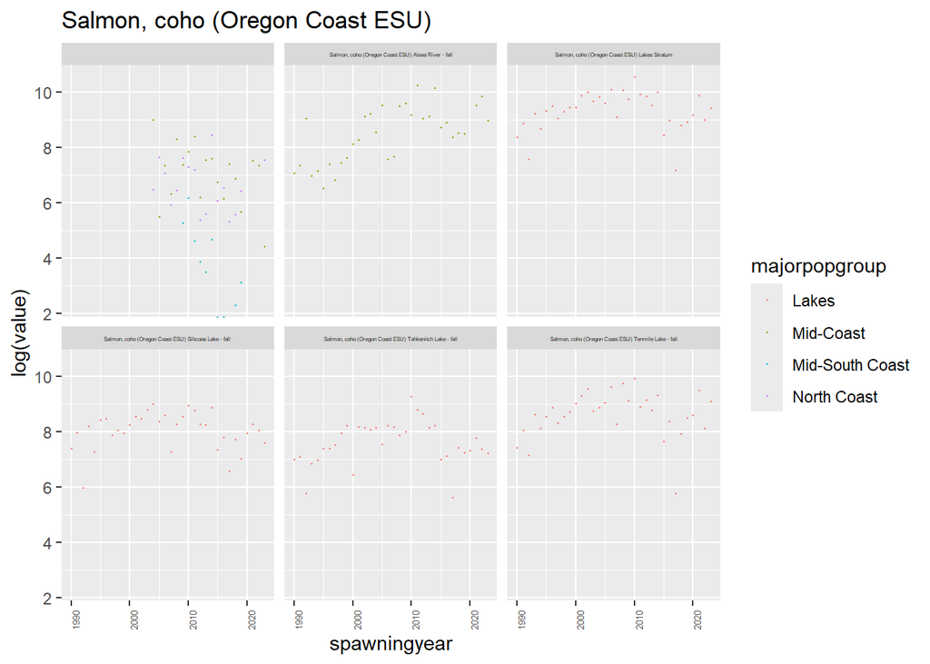

```
## [1] 21
```

# General Questions

1. Create estimates of spawner abundance for all missing years and provide estimates of the decline from the historical abundance.
2. Evaluate support for the major population groups. Are the populations in the groups more correlated than outside the groups?
3. Evaluate the evidence of cycling in the data.

# Methods

### Question 1

To create estimates of spawner abundance, we fit an unbiased random walk model using the MARSS function to create estimates of the “states” or x values. For this first model, we assumed R and Q are diagonal and equal, and U is equal to zero, thus no bias term will be included in this estimate. Below is a plot of sub-populations with the state estimates and observed spawner abundances.

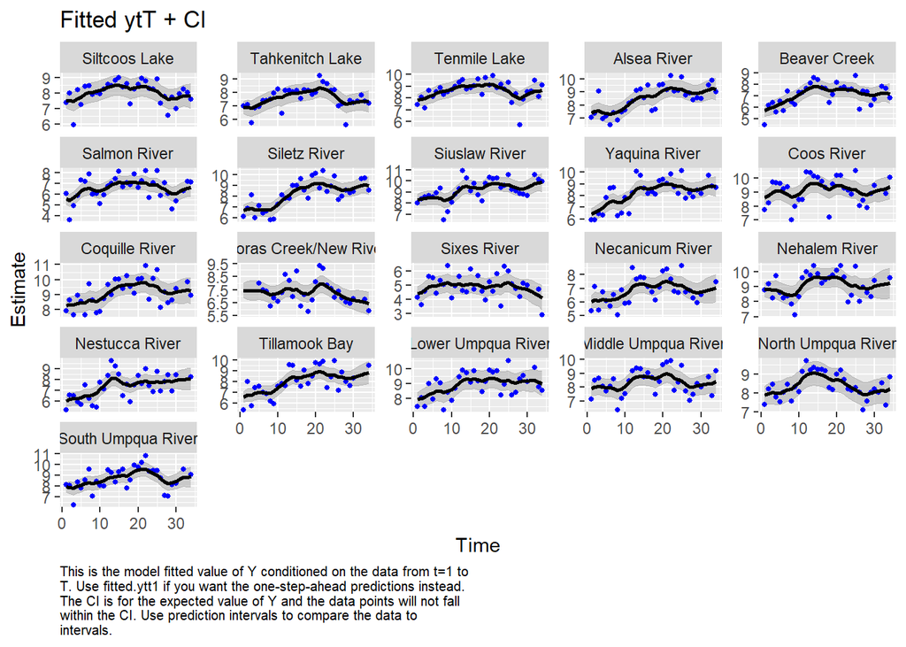

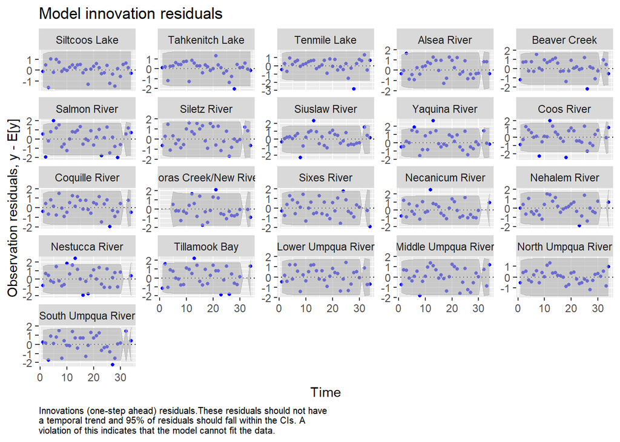

```
## plot.type = model.resids.ytt1
```

[figure not shown]

```
## Hit <Return> to see next plot (q to exit):
```

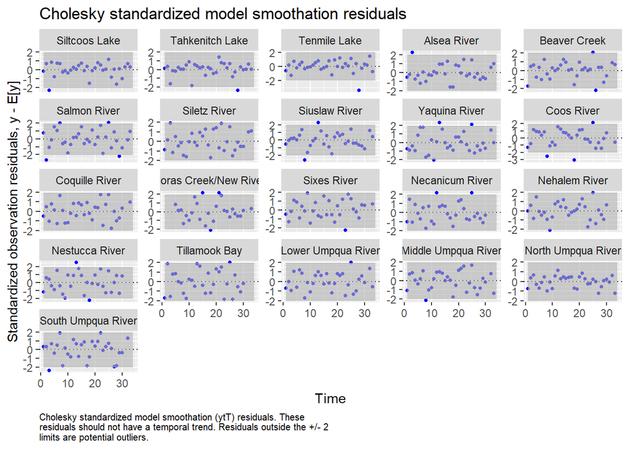

```
## plot.type = std.model.resids.ytT
```

[figure not shown]

```
## Hit <Return> to see next plot (q to exit):
```

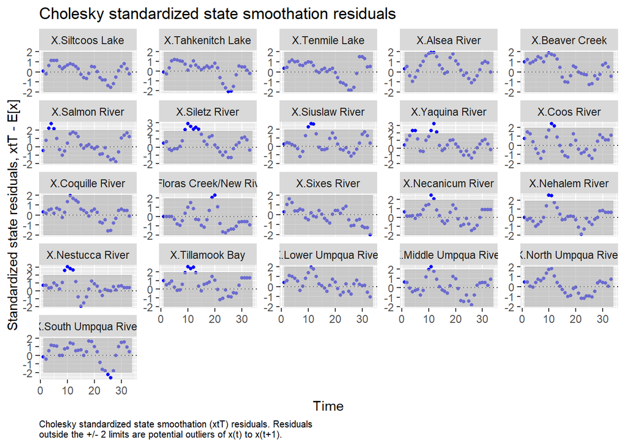

```
## plot.type = std.state.resids.xtT
```

[figure not shown]

```
## Hit <Return> to see next plot (q to exit):
```

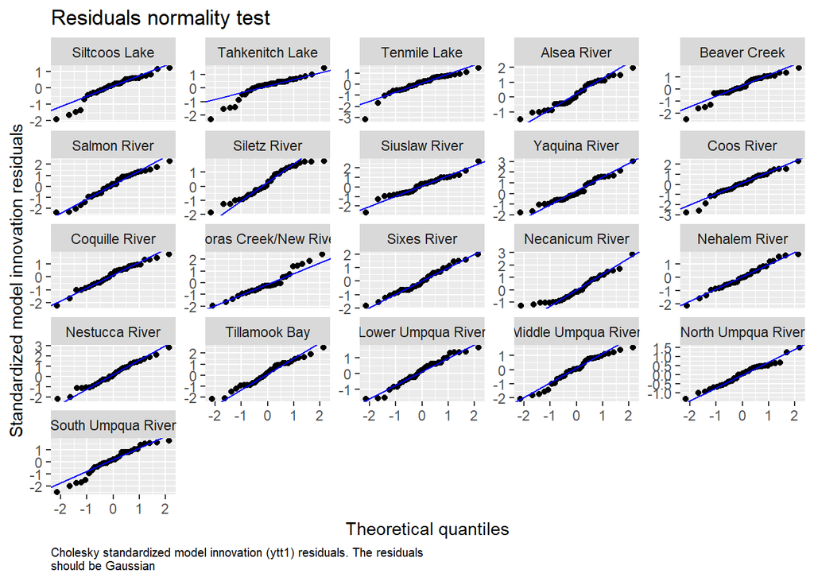

```
## plot.type = qqplot.std.model.resids.ytt1
```

[figure not shown]

```
## Hit <Return> to see next plot (q to exit):
```

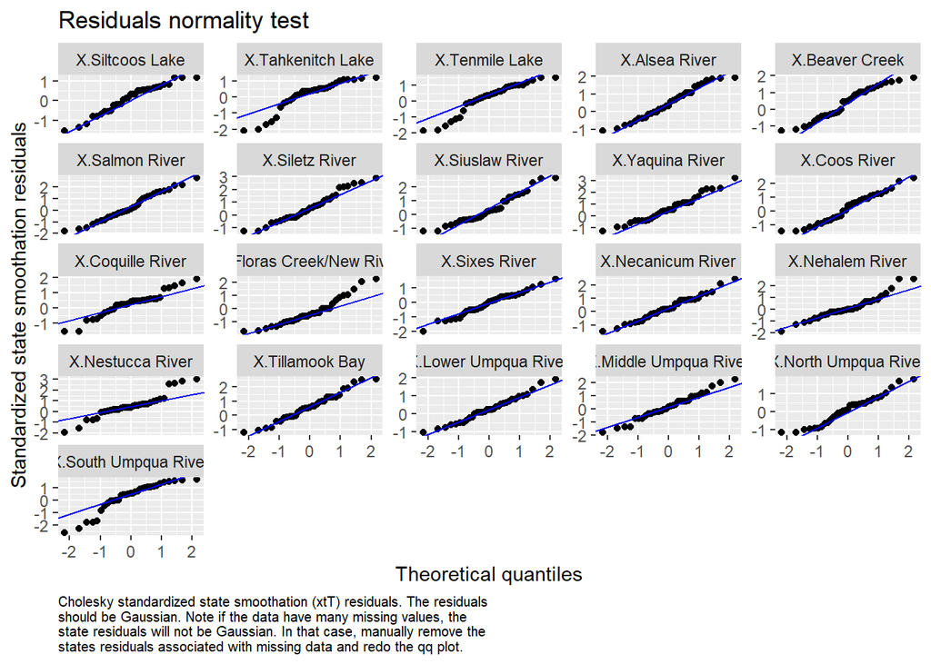

```
## plot.type = qqplot.std.state.resids.xtT
```

[figure not shown]

```
## Hit <Return> to see next plot (q to exit):
```

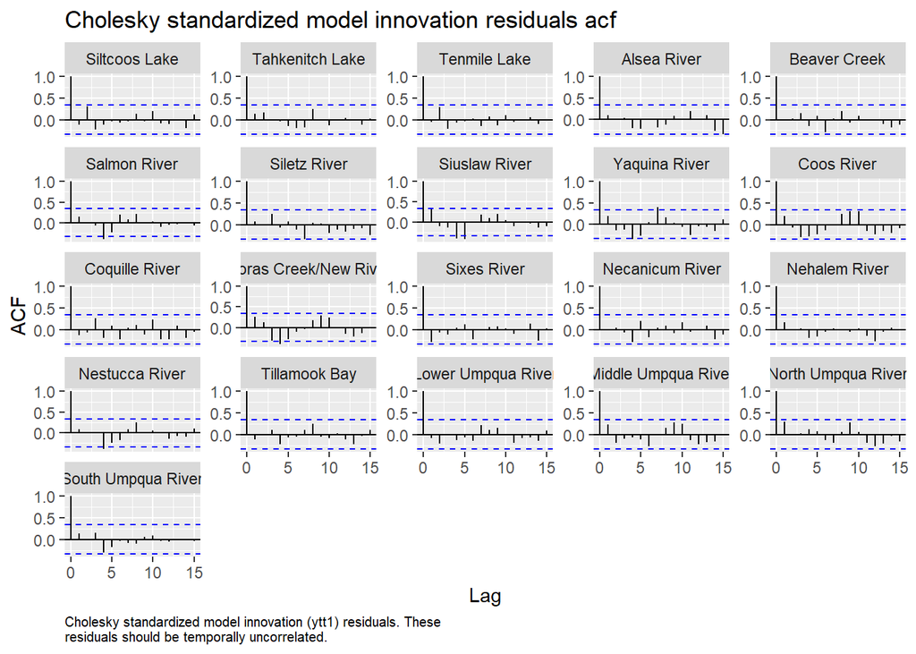

```
## plot.type = acf.std.model.resids.ytt1
```

[figure not shown]

```
## Finished plots.
```

```
##    U Estimate for total ESU
## U=               0.03462017
```

Oregon Coast ESU sub-population U estimates from biased random walk with unequal U terms

```
## Success! abstol and log-log tests passed at 112 iterations.
## Alert: conv.test.slope.tol is 0.5.
## Test with smaller values (<0.1) to ensure convergence.
##
## MARSS fit is
## Estimation method: kem
## Convergence test: conv.test.slope.tol = 0.5, abstol = 0.001
## Estimation converged in 112 iterations.
## Log-likelihood: -866.8162
## AIC: 1821.632   AICc: 1827.869
##
##                             Estimate
## R.diag                       0.55858
## U.X.Siltcoos Lake            0.00837
## U.X.Tahkenitch Lake          0.01463
## U.X.Tenmile Lake             0.02365
## U.X.Alsea River              0.06229
## U.X.Beaver Creek             0.04957
## U.X.Salmon River             0.03389
## U.X.Siletz River             0.08102
## U.X.Siuslaw River            0.05161
## U.X.Yaquina River            0.07797
## U.X.Coos River               0.02171
## U.X.Coquille River           0.03443
## U.X.Floras Creek/New River  -0.03624
## U.X.Sixes River             -0.01005
## U.X.Necanicum River          0.03408
## U.X.Nehalem River            0.01486
## U.X.Nestucca River           0.07073
## U.X.Tillamook Bay            0.07759
## U.X.Lower Umpqua River       0.03660
## U.X.Middle Umpqua River      0.01473
## U.X.North Umpqua River       0.00846
## U.X.South Umpqua River       0.03207
## Q.diag                       0.05319
## x0.X.Siltcoos Lake           7.53414
## x0.X.Tahkenitch Lake         6.89470
## x0.X.Tenmile Lake            7.87540
## x0.X.Alsea River             7.23871
## x0.X.Beaver Creek            5.67751
## x0.X.Salmon River            5.55368
## x0.X.Siletz River            6.44973
## x0.X.Siuslaw River           8.18044
## x0.X.Yaquina River           6.33288
## x0.X.Coos River              8.62729
## x0.X.Coquille River          8.18818
## x0.X.Floras Creek/New River  7.68714
## x0.X.Sixes River             4.60196
## x0.X.Necanicum River         5.97484
## x0.X.Nehalem River           8.74586
## x0.X.Nestucca River          5.89903
## x0.X.Tillamook Bay           6.42000
## x0.X.Lower Umpqua River      7.92487
## x0.X.Middle Umpqua River     7.89383
## x0.X.North Umpqua River      7.93089
## x0.X.South Umpqua River      7.82783
## Initial states (x0) defined at t=0
##
## Standard errors have not been calculated.
## Use MARSSparamCIs to compute CIs and bias estimates.
```

```
##                            U Estimate
## X.Siltcoos Lake           0.008365379
## X.Tahkenitch Lake         0.014630028
## X.Tenmile Lake            0.023650053
## X.Alsea River             0.062290561
## X.Beaver Creek            0.049566947
## X.Salmon River            0.033887107
## X.Siletz River            0.081015785
## X.Siuslaw River           0.051610270
## X.Yaquina River           0.077967980
## X.Coos River              0.021705196
## X.Coquille River          0.034425635
## X.Floras Creek/New River -0.036235181
## X.Sixes River            -0.010052191
## X.Necanicum River         0.034079401
## X.Nehalem River           0.014856241
## X.Nestucca River          0.070725069
## X.Tillamook Bay           0.077593015
## X.Lower Umpqua River      0.036598112
## X.Middle Umpqua River     0.014728945
## X.North Umpqua River      0.008457108
## X.South Umpqua River      0.032074398
```

### Question 2

The Oregon Coast Coho ESU is divided into five “major population groups” (MPGs), based on biological or geographical similarities. In this question, we test whether these groups reflect real ecological patterns—specifically, whether populations within the same MPG show more similar (i.e., correlated) abundance trends than populations in different groups.

AICc results when unequal drift is assumed:

```
## # A tibble: 3 × 3
##   model        num_states  AICc
##   <chr>             <int> <dbl>
## 1 Site-level           21 1451.
## 2 5-group MPG           5 1464.
## 3 1-population          1 1511.
```

These models allowed us to test how different grouping structures affect the model fit. We tested three grouping assumptions using the Z matrix: one group for all sites, one group per site, and the original five major population groups (MPGs) defined in the dataset.

The Z matrix determines how each observed population is linked to the hidden states. Below is a simplified example of the Z matrix used for the five-group MPG model:

$$Z =
\begin{bmatrix}
1 & 0 & 0 & 0 & 0 \\
1 & 0 & 0 & 0 & 0 \\
0 & 1 & 0 & 0 & 0 \\
0 & 1 & 0 & 0 & 0 \\
0 & 0 & 1 & 0 & 0 \\
0 & 0 & 0 & 1 & 0 \\
\vdots & \vdots & \vdots & \vdots & \vdots \\
0 & 0 & 0 & 0 & 1 \\
\end{bmatrix}$$

Each row corresponds to a population time series, and each column represents a hidden state. This setup assumes that populations within the same MPG share a common trend.

Under the assumption of unequal drift (U = unequal), the model that assigned one hidden state to **each site** performed best. However, the estimated drift values were generally small and centered near zero. When we assumed equal or zero drift (U = equal or U = zero), the five-group MPG model was best supported.

This suggests that while site-specific variation exists, the MPG groupings are biologically reasonable and are supported by the data.

AICc results when zero drift is assumed:

```
## # A tibble: 3 × 3
##   model        num_states  AICc
##   <chr>             <int> <dbl>
## 1 5-group MPG           5 1473.
## 2 Site-level           21 1492.
## 3 1-population          1 1509.
```

AICc results when equal drift is assumed:

```
## # A tibble: 3 × 3
##   model        num_states  AICc
##   <chr>             <int> <dbl>
## 1 5-group MPG           5 1475.
## 2 Site-level           21 1494.
## 3 1-population          1 1511.
```

The comparison of these models changes when the assumption of population trend is changed. When equal or zero drift is assumed, the 5-group MPG performs best. When unequal drift is assumed, the site-level model performs best. This could suggest there is an alternative grouping that could explain the variation in population trends observed in the Oregon Coast ESU. Also of note, when we compare the 5-group model AICc values to each other when the population trend assumptions are changed, the unequal drift model performs best. This supports the assumption of unequal population trends (U-term). One hypothesis is that these population trends can be explained by changing the assumptions of groupings for these ESU sub-populations. To test this hypothesis, we fit several alternative models with different grouping structures to the Oregon Coast ESU sub-populations. We maintain the assumption of hidden states that are allowed to correlate (models fit with this assumption performed better than other assumptions about Q; see AICc results below)

```
## # A tibble: 3 × 3
##   model                   num_states  AICc
##   <chr>                        <int> <dbl>
## 1 Q=equalvarcov                    5 1464.
## 2 Q=diagonal and equal             5 1563.
## 3 Q= diagonal and unequal          5 1570.
```

First we fit alternative groupings that divided the ESU into 6 groups. One model separated Beaver Creek and Salmon River into a sixth group, since they geographically distant from the other sub-populations (more inland). The other 6-group model separated Floras Creek and Sixes River into a sixth group. These were the two populations experiencing declining population trends, and are further south than most of the other sites, which could mean they form a unique group. We also fit a model with 7 groupings, with groups 6 and 7 being the sub-groups described previously.

AICc results for splitting the groups into 6 and 7 groups:

```
## # A tibble: 4 × 3
##   model                   num_states  AICc
##   <chr>                        <int> <dbl>
## 1 Beaver and Salmon group          6 1457.
## 2 Flores and Sixes Group           6 1461.
## 3 7 Groups                         7 1461.
## 4 5-Group MPG                      5 1464.
```

The first alternative 5 group model divided the sub-populations up equally along a north-south gradient, and the second model set Beaver Creek and Salmon River, and Floras Creek and Sixes River into their own groups, and combined the coastal groups into one.

None of these performed better than the original 5-group model.

```
## # A tibble: 3 × 3
##   model                  num_states  AICc
##   <chr>                       <int> <dbl>
## 1 5-Group MPG                     5 1464.
## 2 Combined Coastal Group          5 1465.
## 3 North-South groups              5 1485.
```

Next we tried fitting models with fewer than 5 groups: one there is no lake group (merged with mid-Coast), two where there is no umpqua group (one merged with mid-south coast, in the other one it is merged with the mid-coast group), one in which there three groups- coastal, lake, and upmqua, and one in which there are only three coastal groups.

```
## # A tibble: 6 × 3
##   model                     num_states  AICc
##   <chr>                          <int> <dbl>
## 1 5-Group MPG                        5 1464.
## 2 Umpqua in Mid-South Coast          4 1471.
## 3 Lake, Coast, Umpqua                3 1482.
## 4 3 Coastal                          3 1502.
## 5 Umpqua in Mid-Coast                4 1503.
## 6 No Lakes                           4 1505.
```

### Question 3

To further explore variation in population trends over time for the Oregon Coast ESU, we evaluate the evidence of cycling in Oregon Coast coho spawner abundance. We compared three structural approaches using MARSS models: a polynomial trend, a Fourier series (cyclic component), and a null model (the best performed from above analysis). We hypothesized that coho populations might exhibit 4-year cycles due to biological factors.

```
## # A tibble: 3 × 3
##   Model             AICc Delta_AICc
##   <chr>            <dbl>      <dbl>
## 1 Null             1451.         0
## 2 Polynomial       1800.       349.
## 3 Fourier (4-year) 1869.       418.
```

It seems that still the null model performs the best, but we want to systematically test different cycle periods that might be biologically plausible for coho salmon (2-10 years).

# Results

### Estimating Population Trends

Both of the models we fit to estimate population trends for the Oregon Coast ESU populations found they are relatively stable, and have experienced slight increases since 1990. Below is a histogram of the distribution of estimated population trends for each sub-population in this ESU. There is some variation in the population trends among the sub-populations in this ESU, but the Floras Creek/New River and Sixes River fall spawners are the only groups that are experiencing a declining trend.

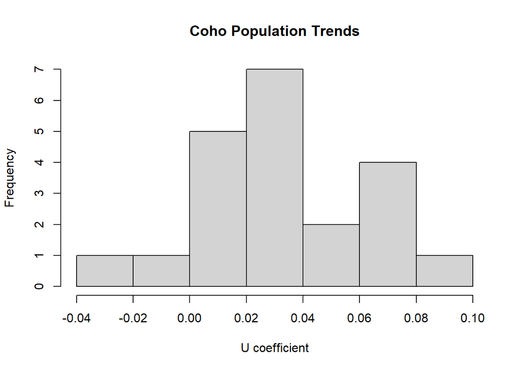

### Visualization of the correlation results:

To better understand the relationships between major population groups, we visualized the correlation matrix (Q) from the MARSS model that assigned one hidden state to each group. The Q matrix reflects how similarly the groups behave over time.

This visual allows us to assess whether some MPGs are tightly linked or behaving independently, even within the group structure.

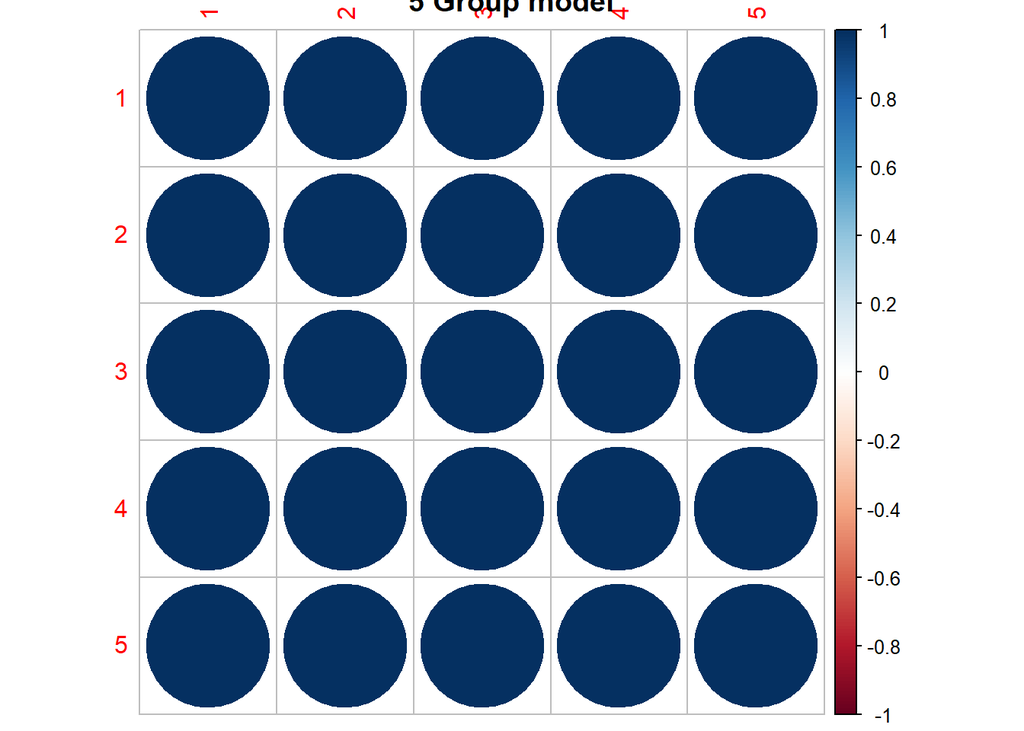

```r
Q <- coef(fit.grp, type="matrix")$Q
corrmat <- diag(1/sqrt(diag(Q))) %*% Q %*% diag(1/sqrt(diag(Q)))
corrplot(corrmat, main="5 Group model")
```

### Interpretation of the Correlation Heatmap

When we assume unequal drift, the site-level model performs slightly better, suggesting that individual sub-populations are experiencing their own distinct trends. However, the 5-group MPG model with unequal drift also performed better than the versions with equal or zero drift, reinforcing the idea that the original groupings are still biologically meaningful.

### Cyclic dynamics

All tested cycle periods (2–10 years) yielded higher AICc values than the null model (ΔAICc > 0), indicating no statistical evidence for cyclic dynamics in Oregon Coast coho spawner abundance (see AICc comparisons below).

```
## # A tibble: 3 × 3
##   Model             AICc Delta_AICc
##   <chr>            <dbl>      <dbl>
## 1 Null             1451.         0
## 2 Polynomial       1800.       349.
## 3 Fourier (4-year) 1869.       418.
```

```
## # A tibble: 9 × 4
##   Period  AICc Delta_AICc Converged
##    <int> <dbl>      <dbl> <lgl>
## 1      9 1736.       285. TRUE
## 2     10 1769.       318. TRUE
## 3      8 1805.       354. TRUE
## 4      7 1835.       385. TRUE
## 5      3 1854.       403. TRUE
## 6      2 1862.       412. TRUE
## 7      6 1867.       417. TRUE
## 8      5 1868.       418. TRUE
## 9      4 1869.       418. TRUE
```

# Discussion

In this lab, we explored population structure, trends, and cyclic dynamics of the Oregon Coast coho salmon ESU. This ESU consists of 21 sub-populations of coho, for which there is time series data of adult returns from 1990 to 2023. We fit MARSS models to the data to investigate the underlying population dynamics of this ESU and found the following:

There is variation in the population trends experienced by the 21 sub-populations; on average, the sub-populations in this ESU have experienced slightly positive trends from their historical abundances in the early 1990’s. Two populations- the Floras Creek and Sixed River- have experienced slight declines.

An alternative hypothesis to population structure driving variation within this ESU is the hypothesis of cyclic dynamics within the time series data. To investigate this, we fit several models with varying cycle periods to the data.

While cyclic dynamics are theoretically plausible for salmonids, this analysis found no empirical support for cyclic trends in Oregon Coast coho spawner abundance at any tested period (2–10 years). The null model’s superiority suggests that population trends are likely driven by non-cyclic factors, and management should prioritize addressing persistent stressors rather than anticipating cyclic rebounds.

The lack of cyclicity suggests that no dominant environmental driver synchronizes populations at these timescales. Populations may be buffered against cyclic pressures by life-history diversity and local adaptation to heterogeneous habitats.

# Description of each team member’s contributions

Nicole addressed question 1 and fit alternative grouping-assumption models in question 2. Mary provided the code for all data visualization and for fitting MARSS models in question 2. Tina addressed question 3. All group members contributed to the write-up and discussion sections of this report.